# NYS Influenza Dataset - Monthly Consolidated 2010-2019

## Longitude

| Feature | Result |
| --- | --- |
| Variable type | numeric |
| Number of missing obs. | 0 (0 %) |
| Number of unique values | 61 |
| Median | -75 |
| 1st and 3rd quartiles | -76.87; -73.97 |
| Min. and max. | -79.41; -72.69 |

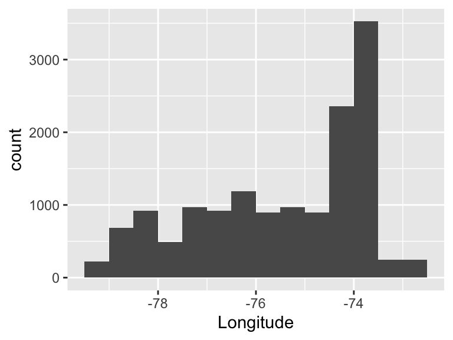

## Incidents

| Feature | Result |
| --- | --- |
| Variable type | integer |
| Number of missing obs. | 0 (0 %) |
| Number of unique values | 596 |
| Median | 0 |
| 1st and 3rd quartiles | 0; 8 |
| Min. and max. | 0; 4277 |

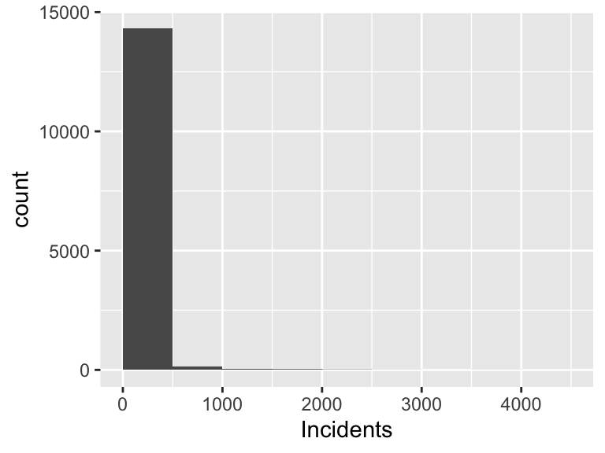

Report generation information:

- Created by Dan Truong (username: `truong`).
- Report creation time: Tue Nov 05 2019 14:38:55
- Report was run from directory: `/Users/truong/Documents/GitHub/NYS-Influenza-Map`
- dataMaid v1.3.2 [Pkg: 2019-07-27 from CRAN (R 3.6.0)]
- R version 3.6.1 (2019-07-05).
- Platform: x86_64-apple-darwin15.6.0 (64-bit)(macOS Mojave 10.14.6).
- Function call: `makeDataReport(data = fluDataCons, mode = c("summarize", "visualize", "check"), smartNum = FALSE, file = "codebook/codebook.Rmd", checks = list( character = "showAllFactorLevels", factor = "showAllFactorLevels", labelled = "showAllFactorLevels", haven_labelled = "showAllFactorLevels", numeric = NULL, integer = NULL, logical = NULL, Date = NULL), listChecks = FALSE, maxProbVals = Inf, codebook = TRUE, reportTitle = "NYS Influenza Dataset - Monthly Consolidated 2010-2019")`